# Limite Cheque Especial

Marcio Cruz

28/06/2021

## Case

Uma instituição financeira tem o objetivo de estimar o valor de Limite de Cheque Especial para seus novos clientes, com base em informações disponíveis em seu banco de dados. Para o estudo, foi disponibilizada uma amostra histórica de clientes com as informações de Idade, Rendimento Total, Salário, Limite de Crédito Imediato, Escolaridade, Gênero e Região para investigar se é possível estimar o Limite do Cheque Especial. Avalie a possibilidade de fornecer uma “regra” por meio de um modelo estatístico, interprete como as informações predizem o evento de interesse e qual a performance desta “regra”.

## Respostas

### a) Faça o gráfico de dispersão entre as variáveis.

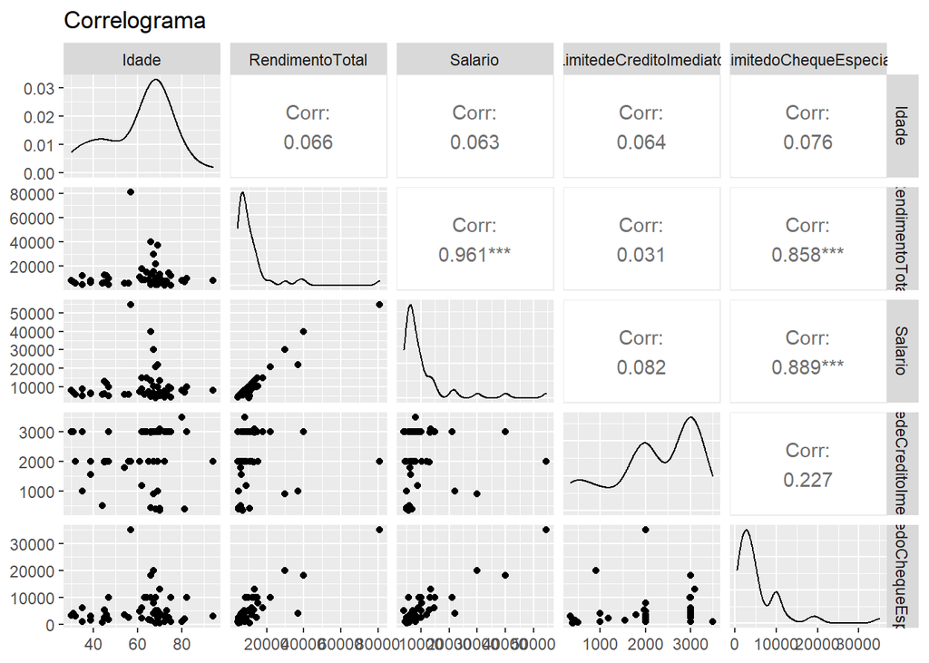

### b) Calcule o coeficiente de correlação entre as variáveis quantitativas. Interprete os coeficientes.

**Interpretação:** Os coeficientes estão no item “a”. As variáveis de Salário e e Rendimento TOtal possuem multicolinearidade entre si. Assim, adotou-se avariável com a maior correlação que é salário.

### c) Obtenha o modelo de regressão linear múltipla e faça a seleção de variáveis pelo método Backward

```r
regressao1 <- lm(data = dados_lim_cred, formula = LimitedoChequeEspecial ~ Idade + Salario + LimitedeCreditoImediato)
summary(regressao1)
```

```
##
## Call:
## lm(formula = LimitedoChequeEspecial ~ Idade + Salario + LimitedeCreditoImediato,
##     data = dados_lim_cred)
##
## Residuals:
##     Min      1Q  Median      3Q     Max
## -7078.6 -1302.6  -220.6  1047.9  6201.9
##
## Coefficients:
##                            Estimate  Std. Error t value            Pr(>|t|)
## (Intercept)             -2886.78469  1876.25053  -1.539              0.1311
## Idade                       4.32030    26.58314   0.163              0.8716
## Salario                     0.57528     0.04292  13.402 <0.0000000000000002 ***
## LimitedeCreditoImediato     1.01120     0.42704   2.368              0.0223 *
## ---
## Signif. codes:  0 '***' 0.001 '**' 0.01 '*' 0.05 '.' 0.1 ' ' 1
##
## Residual standard error: 2732 on 44 degrees of freedom
## Multiple R-squared:  0.8141, Adjusted R-squared:  0.8014
## F-statistic: 64.23 on 3 and 44 DF,  p-value: 0.0000000000000004093
```

```r
regressao2 <- lm(data = dados_lim_cred, formula = LimitedoChequeEspecial ~ Salario + LimitedeCreditoImediato)
summary(regressao2)
```

```
##
## Call:
## lm(formula = LimitedoChequeEspecial ~ Salario + LimitedeCreditoImediato,
##     data = dados_lim_cred)
##
## Residuals:
##     Min      1Q  Median      3Q     Max
## -7043.8 -1313.0  -249.4  1028.4  6209.2
##
## Coefficients:
##                            Estimate  Std. Error t value            Pr(>|t|)
## (Intercept)             -2636.56049  1060.62552  -2.486              0.0167 *
## Salario                     0.57568     0.04239  13.582 <0.0000000000000002 ***
## LimitedeCreditoImediato     1.01532     0.42165   2.408              0.0202 *
## ---
## Signif. codes:  0 '***' 0.001 '**' 0.01 '*' 0.05 '.' 0.1 ' ' 1
##
## Residual standard error: 2703 on 45 degrees of freedom
## Multiple R-squared:  0.814,  Adjusted R-squared:  0.8057
## F-statistic: 98.47 on 2 and 45 DF,  p-value: < 0.00000000000000022
```

```r
regressao3 <- lm(data = dados_lim_cred, formula = LimitedoChequeEspecial ~ Salario)
summary(regressao3)
```

```
##
## Call:
## lm(formula = LimitedoChequeEspecial ~ Salario, data = dados_lim_cred)
##
## Residuals:
##     Min      1Q  Median      3Q     Max
## -8332.9 -1716.6  -596.4  1301.5  7086.8
##
## Coefficients:
##               Estimate Std. Error t value            Pr(>|t|)
## (Intercept) -515.74745  620.97658  -0.831               0.411
## Salario        0.58403    0.04439  13.156 <0.0000000000000002 ***
## ---
## Signif. codes:  0 '***' 0.001 '**' 0.01 '*' 0.05 '.' 0.1 ' ' 1
##
## Residual standard error: 2840 on 46 degrees of freedom
## Multiple R-squared:   0.79,  Adjusted R-squared:  0.7855
## F-statistic: 173.1 on 1 and 46 DF,  p-value: < 0.00000000000000022
```

### d) Interprete os parâmetros do modelo e o coeficiente de determinação

**Interpretação:** Feito a comparação entre as variáveis Idade, Salário e Limite de Crédito Imediato e, adotou-se o modelo que possui Salário e Limite de Crédito Imediato como variáveis resposta, já que possuem o maior R2 ajustado.

### e) Apresente a equação do modelo estimado

y_estimado <- -2636.5649 + 0.57568 . x.salario + 1.01532 . x.limite_credito_imediato